# Práctica 1 Machine learning

Raquel Fort Serra

07/11/2019

# Objetivos

En la siguiente práctica se pretende analizar la influencia en las notas de matemáticas de los estudiantes que tienen algunas variables como el sexo, la raza, el nivel educativo de los padres, el poder adquisitivo familiar (descrito implícitamente en el tipo de comida como explicaré más adelante en la descripción de las variables) y la participación o no de estos alumnos en cursos de preparación de exámenes.

# Descripción de las variables

El dataset que voy a utilizar proviene de la plataforma Kaggle. Dicha base de datos cuenta con la información de 1000 estudiantes. Las variables referentes a dichos estudiantes son las siguientes:

- "Math score" hace referencia a la nota sacada en matemáticas para cada alumno.
- "Reading score" hace referencia a la nota sacada en lecturapara cada alumno.
- "Writing score" hace referencia a la nota sacada en escriturapara cada alumno.
- La variable "Gender" plasma si el alumno es hombre o mujer.
- "Race/ethnicity" refleja en cada alumno al grupo étinco al que pertenece.
- "Parental level of education" refiere al nivel educativo de los padres.
- "Lunch" determina el tipo de alimentación del alumno en base a la situación económica familiar. Muchas escuelas de los EEUU proporcionan comida gratuita a los estudiantes cuyas familias tienen dificultades económicas. La variable 'lunch' de los alumnos que reciben este tipo de ayudas en las comidas adquirirá el valor de "free/reduced lunch". En caso contrario, esta variable tomará el valor de "standard lunch".
- "Test preparation course" señala si el alumno ha recibido cursos de preparación para los exámenes o no.

# 1. Preprocesamiento de los datos

En primer lugar se importan las herramientas necesarias para cargar los datos y realizar el análisis exploratorio:

```python
import pandas as pd # data processing
import numpy as np # linear algebra
import matplotlib.pyplot as plt
import seaborn as sns
import warnings
warnings.filterwarnings("ignore")
```

Importamos la base de datos

```python
df = pd.read_csv('StudentsPerformance.csv')
```

Se realiza una pequeña previsualización de los datos para garantizar que todo se ha leído de manera correcta.

```python
nRow, nCol = df.shape
print(f'There are {nRow} rows and {nCol} columns')
```

```
There are 1000 rows and 8 columns
```

```python
list(df) #nos muestra una lista con el nombre de todas las variables de mi base de datos
```

```
['gender',
 'race/ethnicity',
 'parental level of education',
 'lunch',
 'test preparation course',
 'math score',
 'reading score',
 'writing score']
```

```python
df.head() #visualizamos las 5 primeras observaciones
```

|  | gender | race/ethnicity | parental level of education | lunch | test preparation course | math score | reading score | writing score |
| --- | --- | --- | --- | --- | --- | --- | --- | --- |
| 0 | female | group B | bachelor's degree | standard | none | 72 | 72 | 74 |
| 1 | female | group C | some college | standard | completed | 69 | 90 | 88 |
| 2 | female | group B | master's degree | standard | none | 90 | 95 | 93 |
| 3 | male | group A | associate's degree | free/reduced | none | 47 | 57 | 44 |
| 4 | male | group C | some college | standard | none | 76 | 78 | 75 |

```python
df.tail() # y las 5 úlimas
```

|  | gender | race/ethnicity | parental level of education | lunch | test preparation course | math score | reading score | writing score |
| --- | --- | --- | --- | --- | --- | --- | --- | --- |
| 995 | female | group E | master's degree | standard | completed | 88 | 99 | 95 |
| 996 | male | group C | high school | free/reduced | none | 62 | 55 | 55 |
| 997 | female | group C | high school | free/reduced | completed | 59 | 71 | 65 |
| 998 | female | group D | some college | standard | completed | 68 | 78 | 77 |
| 999 | female | group D | some college | free/reduced | none | 77 | 86 | 86 |

```python
df.isnull().sum()# Podemos ver que no hay 'missing values'
```

```
gender                         0
race/ethnicity                 0
parental level of education    0
lunch                          0
test preparation course        0
math score                     0
reading score                  0
writing score                  0
dtype: int64
```

```python
df.describe()
# Podemos ver las estadísticas descriptivas de las variables numéricas
# como el recuento total, la media, la desviación estándar, los valores
# mínimos y máximos y tres cuantiles de los datos (25%, 50%, 75%)
```

|  | math score | reading score | writing score |
| --- | --- | --- | --- |
| count | 1000.00000 | 1000.000000 | 1000.000000 |
| mean | 66.08900 | 69.169000 | 68.054000 |
| std | 15.16308 | 14.600192 | 15.195657 |
| min | 0.00000 | 17.000000 | 10.000000 |
| 25% | 57.00000 | 59.000000 | 57.750000 |
| 50% | 66.00000 | 70.000000 | 69.000000 |
| 75% | 77.00000 | 79.000000 | 79.000000 |
| max | 100.00000 | 100.000000 | 100.000000 |

```python
df.info()
```

```
<class 'pandas.core.frame.DataFrame'>
RangeIndex: 1000 entries, 0 to 999
Data columns (total 8 columns):
gender                         1000 non-null object
race/ethnicity                 1000 non-null object
parental level of education    1000 non-null object
lunch                          1000 non-null object
test preparation course        1000 non-null object
math score                     1000 non-null int64
reading score                  1000 non-null int64
writing score                  1000 non-null int64
dtypes: int64(3), object(5)
memory usage: 62.6+ KB
```

Podemos ver que tenemos 2 tipos de variables:

- Variables numéricas: que contiene números como valores
- Variables categóricas: que contiene descripciones de grupos o cosas.

En este conjunto de datos, las variables numéricas son "Math score", "Reading score" and "Writing score". Las variables categóricas son "Gender", "Race/ethnicity", "Parental level of education", "Lunch" and "Test preparation course".

# Visualización de los datos

Echamos un vistazo a nuestros datos.

Hacemos un recuentode variables categóricas.

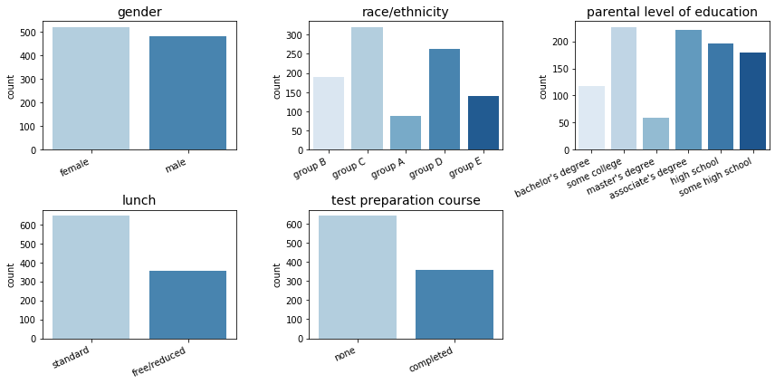

```python
in_cols = ['gender', 'race/ethnicity', 'parental level of education', 'lunch',
       'test preparation course']
fig,axarr = plt.subplots(2,3,figsize=(12,6))
axarr[-1, -1].axis('off')
for id,col in enumerate(in_cols):
    ax = axarr.flat[id]
    sns.countplot(x=col, data=df,ax=ax, palette='Blues')
    ax.set_title(col,fontsize=14)
    ax.set_xlabel('')
    plt.setp(ax.get_xticklabels(), rotation=25,ha='right')
plt.tight_layout()
plt.show()
```

¿Qué factores se correlacionan con puntuaciones bajas?

Aquí observamos que los estudiantes con notas inferiores a 40 (suspenso) en al menos una materia suelen ser mujeres, del grupo étnico C, cuyos padres tienen como nivel de educación la educacion secundaria obligatoria o similar. Además la mayoría de estos alumnos son beneficiarios de la comida gratuita y no han asistido a cursos de preparación para los exámenes.

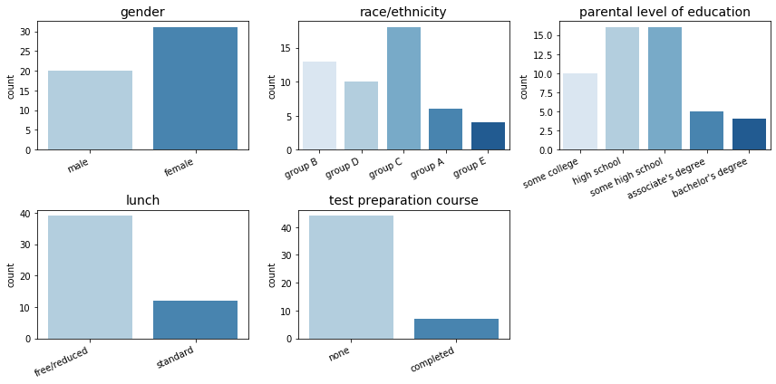

```python
Low_df = df[(df['math score']<40) | (df['reading score']<40) | (df['writing score']<40)]
in_cols = ['gender', 'race/ethnicity', 'parental level of education', 'lunch',
       'test preparation course']
fig,axarr = plt.subplots(2,3,figsize=(12,6))
axarr[-1, -1].axis('off')
for id,col in enumerate(in_cols):
    ax = axarr.flat[id]
    sns.countplot(x=col, data=Low_df,ax=ax, palette='Blues')
    ax.set_title(col,fontsize=14)
    ax.set_xlabel('')
    plt.setp(ax.get_xticklabels(), rotation=25,ha='right')
plt.tight_layout()
plt.show()
```

# Análisis Exploratorio de los datos

##### Distribución de datos

Ahora vamos a trazar la distribución de las notas de los estudiantes (variables numéricas).

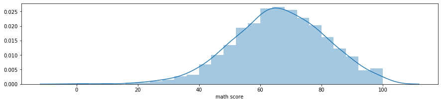

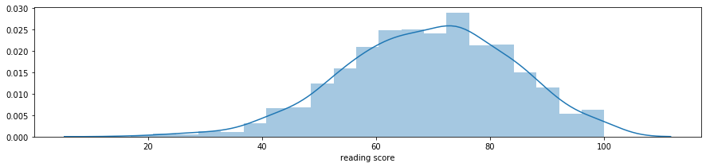

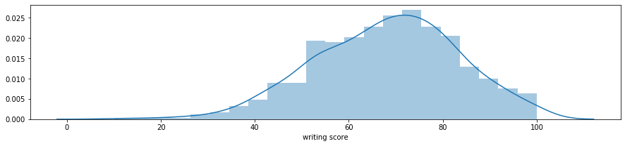

```python
columns_float = [i for i in df.columns if (df[i].dtypes == np.float) | (df[i].dtypes == np.int)]
for i in columns_float:
    plt.subplots(figsize=[15,3])
    sns.distplot(df[i])
```

Podemos ver que las notas siguen una distribución aparentemente normal.

- La mayoría de los estudiantes obtienen en matemáticas una nota que oscila entre 60 y 80
- La mayoría de los estudiantes obtienen en lectura una nota que oscila entre 60 y 80
- La mayoría de los estudiantes obtienen en escritura una nota que oscila entre 60 y 80

##### Correlaciones

A continuación vamos a ver las correlaciones entre las variables numéricas

```python
corr = df.corr()
corr
```

|  | math score | reading score | writing score |
| --- | --- | --- | --- |
| math score | 1.000000 | 0.817580 | 0.802642 |
| reading score | 0.817580 | 1.000000 | 0.954598 |
| writing score | 0.802642 | 0.954598 | 1.000000 |

```python
def correlation_matrix(df, name='Correlation matrix'):
    columns = [i for i in df.columns]
    corr_matrix = df[columns].corr(method='pearson')
    cmap = sns.diverging_palette(220, 10, as_cmap=True)
    mask = np.zeros_like(corr_matrix, dtype=np.bool)
    mask[np.triu_indices_from(mask)] = True
    plt.subplots(figsize=[15,9])
    plt.title(name)
    sns.heatmap(corr_matrix, mask=mask, cmap=cmap, linewidths=.5)
    plt.show()
```

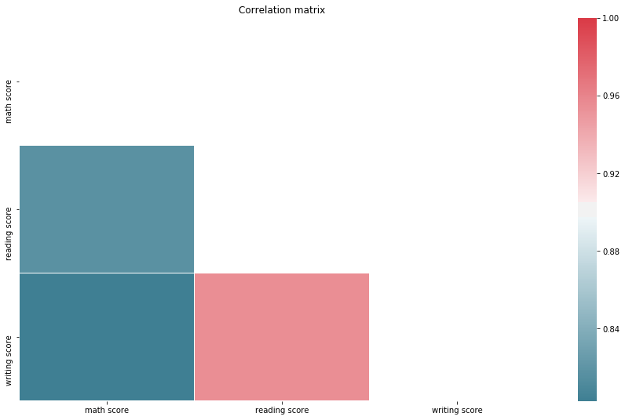

```python
correlation_matrix(df, name='Correlation matrix')
```

Existe una fuerte correlación entre todas ellas. Siendo mayor la correlación entre las notas de esritura y lectura (algo que tiene sentido ya que son asignaturas que van más de la mano).

Como la variable que nos interesa es la de las notas de matemáticas, vamos a ver cómo se relaciona esta variable con el resto.

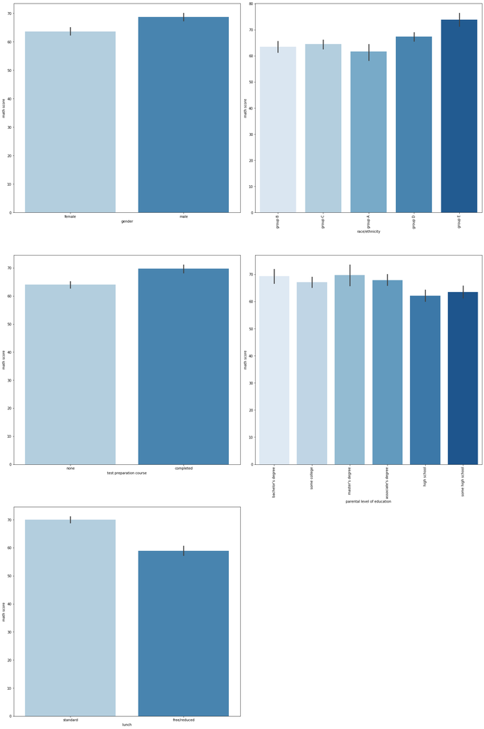

```python
plt.figure(figsize=(20,30))

plt.subplot(3,2,1)
sns.barplot(x = 'gender', y = 'math score', data = df, palette='Blues')

plt.subplot(3,2,2)
sns.barplot(x = 'race/ethnicity', y = 'math score', data = df, palette='Blues')
plt.xticks(rotation = 90)

plt.subplot(3,2,3)
sns.barplot(x = 'test preparation course', y = 'math score', data = df, palette='Blues')

plt.subplot(3,2,4)
sns.barplot(x = 'parental level of education', y = 'math score', data = df, palette='Blues')
plt.xticks(rotation = 90)


plt.subplot(3,2,5)
sns.barplot(x = 'lunch', y = 'math score', data = df, palette='Blues')


plt.tight_layout()
```

Observamos que en matemáticas, tienen una nota mayor los estudiantes hombres, pertenecientes al grupo étnico E, que han realizado cursos de preparación de exámenes, cuyos padres tienen estudios superiores y cuya alimentación es estándar, es decir, no reciben ningún tipo de ayuda.

##### Outliers

A continuación vamos a observar los outliers o valores atípicos en las distintas variables. Un valor atípico es una observación que se encuentra a una distancia anormal de otros valores en la muestra.

En el siguiente gráfico observamos que para cada asignatura, hay alumnos con notas alejadas de los demás valores de la muestra.

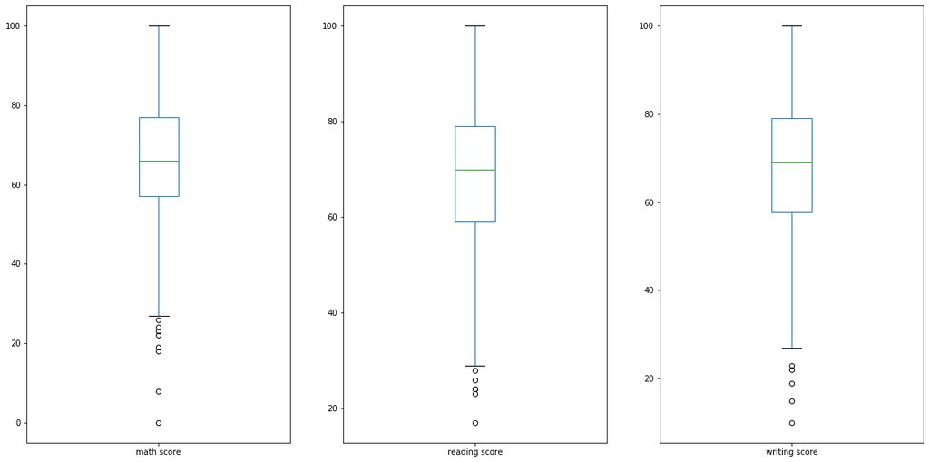

```python
df.plot(kind = 'box', subplots = True, sharex = False, sharey = False)
plt.gcf().set_size_inches(20,10)
plt.show()
```

En el siguiente gráfico observmos los valores atípicos para la nota de matemáticas con respecto a las distintas variables.

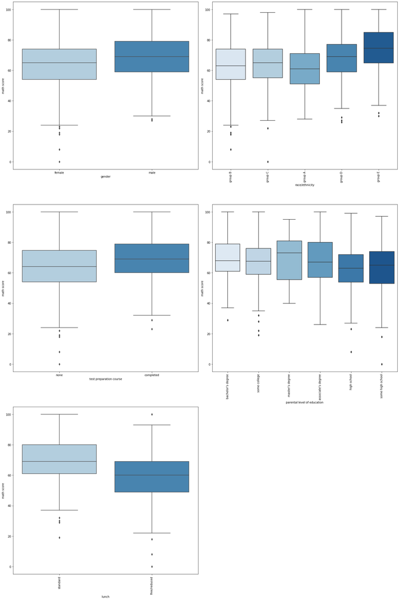

```python
plt.figure(figsize=(20,30))

plt.subplot(3,2,1)
sns.boxplot(x = 'gender', y = 'math score', data = df, palette='Blues')

plt.subplot(3,2,2)
sns.boxplot(x = 'race/ethnicity', y = 'math score', data = df, palette='Blues')
plt.xticks(rotation = 90)

plt.subplot(3,2,3)
sns.boxplot(x = 'test preparation course', y = 'math score', data = df, palette='Blues')

plt.subplot(3,2,4)
sns.boxplot(x = 'parental level of education', y = 'math score', data = df, palette='Blues')
plt.xticks(rotation = 90)

plt.subplot(3,2,5)
sns.boxplot(x = 'lunch', y = 'math score', data = df, palette='Blues')
plt.xticks(rotation = 90)

plt.tight_layout()
```

Los valores atípicos deben investigarse cuidadosamente ya que suelen contener información valiosa, hay que entender por qué aparecen y si es probable que continúen apareciendo valores similares.

##### Creación de variables dummies

A continuación vamos a transformar las variables categóricas en variables 'dummies' para poder implementarlas en nuestro modelo (requiere matrices numéricas como datos de entrada)

```python
pd.get_dummies(df).describe()
```

|  | math score | reading score | writing score | gender_female | gender_male | race/ethnicity_group A | race/ethnicity_group B | race/ethnicity_group C | race/ethnicity_group D | race/ethnicity_group E | parental level of education_associate's degree | parental level of education_bachelor's degree | parental level of education_high school | parental level of education_master's degree | parental level of education_some college | parental level of education_some high school | lunch_free/reduced | lunch_standard | test preparation course_completed | test preparation course_none |
| --- | --- | --- | --- | --- | --- | --- | --- | --- | --- | --- | --- | --- | --- | --- | --- | --- | --- | --- | --- | --- |
| count | 1000.00000 | 1000.000000 | 1000.000000 | 1000.000000 | 1000.000000 | 1000.000000 | 1000.000000 | 1000.000000 | 1000.000000 | 1000.000000 | 1000.000000 | 1000.00000 | 1000.000000 | 1000.000000 | 1000.000000 | 1000.000000 | 1000.000000 | 1000.000000 | 1000.000000 | 1000.000000 |
| mean | 66.08900 | 69.169000 | 68.054000 | 0.518000 | 0.482000 | 0.089000 | 0.190000 | 0.319000 | 0.262000 | 0.140000 | 0.222000 | 0.11800 | 0.196000 | 0.059000 | 0.226000 | 0.179000 | 0.355000 | 0.645000 | 0.358000 | 0.642000 |
| std | 15.16308 | 14.600192 | 15.195657 | 0.499926 | 0.499926 | 0.284886 | 0.392497 | 0.466322 | 0.439943 | 0.347161 | 0.415799 | 0.32277 | 0.397167 | 0.235743 | 0.418448 | 0.383544 | 0.478753 | 0.478753 | 0.479652 | 0.479652 |
| min | 0.00000 | 17.000000 | 10.000000 | 0.000000 | 0.000000 | 0.000000 | 0.000000 | 0.000000 | 0.000000 | 0.000000 | 0.000000 | 0.00000 | 0.000000 | 0.000000 | 0.000000 | 0.000000 | 0.000000 | 0.000000 | 0.000000 | 0.000000 |
| 25% | 57.00000 | 59.000000 | 57.750000 | 0.000000 | 0.000000 | 0.000000 | 0.000000 | 0.000000 | 0.000000 | 0.000000 | 0.000000 | 0.00000 | 0.000000 | 0.000000 | 0.000000 | 0.000000 | 0.000000 | 0.000000 | 0.000000 | 0.000000 |
| 50% | 66.00000 | 70.000000 | 69.000000 | 1.000000 | 0.000000 | 0.000000 | 0.000000 | 0.000000 | 0.000000 | 0.000000 | 0.000000 | 0.00000 | 0.000000 | 0.000000 | 0.000000 | 0.000000 | 0.000000 | 1.000000 | 0.000000 | 1.000000 |
| 75% | 77.00000 | 79.000000 | 79.000000 | 1.000000 | 1.000000 | 0.000000 | 0.000000 | 1.000000 | 1.000000 | 0.000000 | 0.000000 | 0.00000 | 0.000000 | 0.000000 | 0.000000 | 0.000000 | 1.000000 | 1.000000 | 1.000000 | 1.000000 |
| max | 100.00000 | 100.000000 | 100.000000 | 1.000000 | 1.000000 | 1.000000 | 1.000000 | 1.000000 | 1.000000 | 1.000000 | 1.000000 | 1.00000 | 1.000000 | 1.000000 | 1.000000 | 1.000000 | 1.000000 | 1.000000 | 1.000000 | 1.000000 |

```python
dummies = pd.get_dummies(df)
```

```python
dummies = dummies.drop(['math score', 'reading score', 'writing score'], axis = 1)
```

```python
df = df.drop(['gender', 'race/ethnicity', 'parental level of education', 'lunch', 'test preparation course'], axis = 1)
```

```python
dfnew = pd.concat([df, dummies], axis=1)
```

```python
dfnew.head()
```

|  | math score | reading score | writing score | gender_female | gender_male | race/ethnicity_group A | race/ethnicity_group B | race/ethnicity_group C | race/ethnicity_group D | race/ethnicity_group E | parental level of education_associate's degree | parental level of education_bachelor's degree | parental level of education_high school | parental level of education_master's degree | parental level of education_some college | parental level of education_some high school | lunch_free/reduced | lunch_standard | test preparation course_completed | test preparation course_none |
| --- | --- | --- | --- | --- | --- | --- | --- | --- | --- | --- | --- | --- | --- | --- | --- | --- | --- | --- | --- | --- |
| 0 | 72 | 72 | 74 | 1 | 0 | 0 | 1 | 0 | 0 | 0 | 0 | 1 | 0 | 0 | 0 | 0 | 0 | 1 | 0 | 1 |
| 1 | 69 | 90 | 88 | 1 | 0 | 0 | 0 | 1 | 0 | 0 | 0 | 0 | 0 | 0 | 1 | 0 | 0 | 1 | 1 | 0 |
| 2 | 90 | 95 | 93 | 1 | 0 | 0 | 1 | 0 | 0 | 0 | 0 | 0 | 0 | 1 | 0 | 0 | 0 | 1 | 0 | 1 |
| 3 | 47 | 57 | 44 | 0 | 1 | 1 | 0 | 0 | 0 | 0 | 1 | 0 | 0 | 0 | 0 | 0 | 1 | 0 | 0 | 1 |
| 4 | 76 | 78 | 75 | 0 | 1 | 0 | 0 | 1 | 0 | 0 | 0 | 0 | 0 | 0 | 1 | 0 | 0 | 1 | 0 | 1 |

# Training y test

Determinamos las varaibles características y la variable objetivo

```python
X = dfnew.iloc[:,2:] #(ya tenemos math score en primera posicion, así que resulta más fácil
y = dfnew['math score']
```

```python
from sklearn import model_selection
from sklearn.model_selection import train_test_split
X_train, X_test, y_train, y_test = train_test_split(X, y, test_size=0.2, random_state =100)
```

# Modelización

##### Regresión lineal múltiple: ajuste de mínimos cuadrados

Primero, importamos los objetos LinearRegression y cross_val_score. El primero nos permitirá ajustar un modelo lineal, mientras que el segundo objeto realizará la validación cruzada k-fold.

```python
from sklearn.model_selection import cross_val_score
from sklearn.linear_model import LinearRegression
```

```python
lin_reg = LinearRegression().fit(X_train,y_train)
```

```python
LinearRegression?
```

```python
cross_val_score?
```

```python
MSEs = cross_val_score(lin_reg, X_train, y_train)
```

```python
mean_MSE = np.mean(MSEs)
```

```python
print(mean_MSE)
```

```
0.8672494058535393
```

Ahora, veamos si será mejor la regresión Ridge o la Lasso.

##### Ridge

La regresión Ridge es similar a los mínimos cuadrados, excepto que los coeficientes se estiman minimizando una cantidad ligeramente diferente. Busca estimaciones de coeficientes que reducen el RSS, sin embargo, también tienen una penalización por contracción cuando los coeficientes se acercan a cero. Esta penalización tiene el efecto de reducir las estimaciones del coeficiente hacia cero. Un parámetro, λ, controla el impacto de la contracción.

Para la regresión ridge, utilizamos GridSearchCV. Esto nos permitirá realizar automáticamente una validación cruzada de 5 veces con un rango de diferentes parámetros de regularización para encontrar el valor óptimo de alfa.

```python
from sklearn.model_selection import GridSearchCV
from sklearn.linear_model import Ridge
```

```python
ridge = Ridge()
```

```python
parameters = {'alpha': [1e-15, 1e-10, 1e-8, 1e-4, 1e-3, 1e-2, 1, 5, 10, 20]}
```

```python
ridge_regressor = GridSearchCV(ridge, parameters, cv = 5)
```

```python
ridge_regressor.fit(X_train, y_train)
```

```
GridSearchCV(cv=5, error_score='raise-deprecating',
             estimator=Ridge(alpha=1.0, copy_X=True, fit_intercept=True,
                             max_iter=None, normalize=False, random_state=None,
                             solver='auto', tol=0.001),
             iid='warn', n_jobs=None,
             param_grid={'alpha': [1e-15, 1e-10, 1e-08, 0.0001, 0.001, 0.01, 1,
                                   5, 10, 20]},
             pre_dispatch='2*n_jobs', refit=True, return_train_score=False,
             scoring=None, verbose=0)
```

```python
print(ridge_regressor.best_params_)
print(ridge_regressor.best_score_)
```

```
{'alpha': 5}
0.8665060750975228
```

##### Lasso

El LASSO es un método de regresión que implica penalizar el tamaño absoluto de los coeficientes de regresión.

Al penalizar o restringir la suma de los valores absolutos de las estimaciones, hace que algunos de sus coeficientes sean cero. Cuanto mayor es la penalización aplicada, las estimaciones adicionales se reducen a cero. Esto es conveniente cuando queremos una selección automática de características / variables, o cuando se trata de predictores altamente correlacionados, donde la regresión estándar generalmente tendrá coeficientes de regresión que son demasiado grandes.

Seguimos un proceso muy similar a la regresión Ridge:

```python
from sklearn.linear_model import Lasso
```

```python
lasso = Lasso()
```

```python
parameters = {'alpha': [1e-15, 1e-10, 1e-8, 1e-4, 1e-3, 1e-2, 1, 5, 10, 20]}
```

```python
lasso_regressor = GridSearchCV(lasso, parameters, cv = 5)
```

```python
lasso_regressor.fit(X_train, y_train)
```

```
GridSearchCV(cv=5, error_score='raise-deprecating',
             estimator=Lasso(alpha=1.0, copy_X=True, fit_intercept=True,
                             max_iter=1000, normalize=False, positive=False,
                             precompute=False, random_state=None,
                             selection='cyclic', tol=0.0001, warm_start=False),
             iid='warn', n_jobs=None,
             param_grid={'alpha': [1e-15, 1e-10, 1e-08, 0.0001, 0.001, 0.01, 1,
                                   5, 10, 20]},
             pre_dispatch='2*n_jobs', refit=True, return_train_score=False,
             scoring=None, verbose=0)
```

```python
print(lasso_regressor.best_params_)
print(lasso_regressor.best_score_)
```

```
{'alpha': 0.01}
0.8664482241517539
```

## Bibliografía

Bodas, D. (2019). Apuntes Machine Learning. Madrid: CUNEF (Colegio Universitario de Estudios Financieros).

CSV. (2018). Students Performance in Exams. Obtenido de Kaggle: https://www.kaggle.com/spscientist/students-performance-in-exams/kernels

Queralt, R. (2019). Apuntes de Predicción. Madrid: CUNEF (Colegio Universitario de Estudios Financieros).